# Bulk RNA-seq Analysis Using GEO Dataset GSE310456

Pavel Baykalov

2026-05-07

# Abstract

Here, I present a reproducible bulk RNA-seq analysis of public GEO dataset GSE310456. The data offers RNA-seq of gonadal white adipose tissue of 15 diabetes resistant (DR) and 15 diabetes prone (DP) female mice, DR animals are healthy animals and are considered as control group[^1].

# Step-by-Step Procedure

The RNA-seq analysis will consist of data exploration, quality control, data pre-processing, differential expression modelling, data enrichment and biological interpretation. Regarding differential expression modelling (DE), two models from two different packages are going to be used: one from `edgeR` and another from `limma`. The consensus between the models will be presented as the final result of DE modelling.

## Data Discovery and Metadata

First, we download the data GSE310456.

```r
gse <- getGEO("GSE310456", GSEMatrix = TRUE, getGPL = FALSE)
```

```
## Found 1 file(s)
```

```
## GSE310456_series_matrix.txt.gz
```

```r
gse
```

```
## $GSE310456_series_matrix.txt.gz
## ExpressionSet (storageMode: lockedEnvironment)
## assayData: 0 features, 30 samples
##   element names: exprs
## protocolData: none
## phenoData
##   sampleNames: GSM9301643 GSM9301644 ... GSM9301672 (30 total)
##   varLabels: title geo_accession ... tissue:ch1 (45 total)
##   varMetadata: labelDescription
## featureData: none
## experimentData: use 'experimentData(object)'
##   pubMedIds: 41361331
## Annotation: GPL23479
```

0 features, indicates there is no counts matrix. 30 samples include: 15 diabetes resistant (DR) and 15 diabetes prone (DP) animals. And there is 45 columns.

We check the Metadata.

```r
data <- gse[[1]]
experimentData(data)
```

```
## Experiment data
##   Experimenter name: Heike,,Vogel
##   Laboratory:
##   Contact information: heikevogel@dife.de
##   Title: Adipose tissue-derived microRNAs as epigenetic modulators of type 2 diabetes [DPDR_RNASEQ]
##   URL: https://www.ncbi.nlm.nih.gov/geo/query/acc.cgi?acc=GSE310456
##   PMIDs: 41361331
##
##   Abstract: A 50 word abstract is available. Use 'abstract' method.
##   notes:
##    contact_address:
##       Arthur-Scheunert-Allee 114-116
##    contact_city:
##       Nuthetal
##    contact_country:
##       Germany
##    contact_department:
##       Department of Experimental Diabetology
##    contact_email:
##       heikevogel@dife.de
##    contact_institute:
##       German Institute of Human Nutrition Potsdam-Rehbruecke
##    contact_name:
##       Heike,,Vogel
##    contact_state:
##       BRB
##    contact_zip/postal_code:
##       14558
##    contributor:
##       Annette,,Schürmann
## Meriem,,Ouni
## Ratika,,Sehgal
## Neele,,Haacke
## Pascal,,Gottm
## ann
## Markus,,Jähnert
##    geo_accession:
##       GSE310456
##    last_update_date:
##       Dec 17 2025
```

[output cut: 21 more lines]

```
##       Nov 19 2025
##    summary:
##       Diabetes-resistant and diabetes-prone female New Zealand Obese mice were a
## ssessed based on liver fat content and early blood glucose concentrations
## at 10 weeks of age before the onset of T2D. Transcriptome analysis of gona
## dal white adipose tissue revealed genes potentially regulated by epigeneti
## c mechanisms such as miRNAs or DNA methylation.
##    supplementary_file:
##       ftp://ftp.ncbi.nlm.nih.gov/geo/series/GSE310nnn/GSE310456/suppl/GSE310456_
## RNASEQ_counts.xlsx
##    title:
##       Adipose tissue-derived microRNAs as epigenetic modulators of type 2 diabet
## es [DPDR_RNASEQ]
##    type:
##       Expression profiling by high throughput sequencing
```

```r
# Check columns description
varMetadata(data)
```

```
##                         labelDescription
## title                               <NA>
## geo_accession                       <NA>
## status                              <NA>
## submission_date                     <NA>
## last_update_date                    <NA>
## type                                <NA>
## channel_count                       <NA>
## source_name_ch1                     <NA>
## organism_ch1                        <NA>
## characteristics_ch1                 <NA>
## characteristics_ch1.1               <NA>
## characteristics_ch1.2               <NA>
## characteristics_ch1.3               <NA>
## molecule_ch1                        <NA>
## extract_protocol_ch1                <NA>
## extract_protocol_ch1.1              <NA>
## taxid_ch1                           <NA>
## description                         <NA>
## data_processing                     <NA>
## data_processing.1                   <NA>
## data_processing.2                   <NA>
## data_processing.3                   <NA>
## data_processing.4                   <NA>
## platform_id                         <NA>
## contact_name                        <NA>
## contact_email                       <NA>
## contact_department                  <NA>
## contact_institute                   <NA>
## contact_address                     <NA>
## contact_city                        <NA>
## contact_state                       <NA>
## contact_zip/postal_code             <NA>
## contact_country                     <NA>
## data_row_count                      <NA>
## instrument_model                    <NA>
## library_selection                   <NA>
## library_source                      <NA>
## library_strategy                    <NA>
## relation                            <NA>
## relation.1                          <NA>
## supplementary_file_1                <NA>
## disease state:ch1                   <NA>
## Sex:ch1                             <NA>
## strain:ch1                          <NA>
## tissue:ch1                          <NA>
```

No description about the 45 columns!

How the first three rows look like.

```r
head(pData(data),3)
```

```
##            title geo_accession                status submission_date
## GSM9301643   183    GSM9301643 Public on Dec 17 2025     Nov 19 2025
## GSM9301644   184    GSM9301644 Public on Dec 17 2025     Nov 19 2025
## GSM9301645   185    GSM9301645 Public on Dec 17 2025     Nov 19 2025
##            last_update_date type channel_count              source_name_ch1
## GSM9301643      Dec 17 2025  SRA             1 Gonadal white adipise tissue
## GSM9301644      Dec 17 2025  SRA             1 Gonadal white adipise tissue
## GSM9301645      Dec 17 2025  SRA             1 Gonadal white adipise tissue
##            organism_ch1                  characteristics_ch1
## GSM9301643 Mus musculus tissue: Gonadal white adipise tissue
## GSM9301644 Mus musculus tissue: Gonadal white adipise tissue
## GSM9301645 Mus musculus tissue: Gonadal white adipise tissue
##            characteristics_ch1.1 characteristics_ch1.2
## GSM9301643 strain: NZO/HIBomDife           Sex: Female
## GSM9301644 strain: NZO/HIBomDife           Sex: Female
## GSM9301645 strain: NZO/HIBomDife           Sex: Female
##                        characteristics_ch1.3 molecule_ch1
## GSM9301643     disease state: diabetes-prone    total RNA
## GSM9301644 disease state: diabetes-resistant    total RNA
## GSM9301645     disease state: diabetes-prone    total RNA
##                                                                                             extract_protocol_ch1
## GSM9301643 total RNA was extracted using a miRNeasy kit (Qiagen, Germany) as per the manufacturer’s instructions
## GSM9301644 total RNA was extracted using a miRNeasy kit (Qiagen, Germany) as per the manufacturer’s instructions
## GSM9301645 total RNA was extracted using a miRNeasy kit (Qiagen, Germany) as per the manufacturer’s instructions
##                   extract_protocol_ch1.1 taxid_ch1       description
## GSM9301643 done by BGI (Shenzhen, China)     10090 Library name: 183
## GSM9301644 done by BGI (Shenzhen, China)     10090 Library name: 184
## GSM9301645 done by BGI (Shenzhen, China)     10090 Library name: 185
##                                                     data_processing
## GSM9301643 adapters and low-quality reads have been filtered by BGI
## GSM9301644 adapters and low-quality reads have been filtered by BGI
## GSM9301645 adapters and low-quality reads have been filtered by BGI
##                                  data_processing.1
## GSM9301643 alignment to reference with STARv2.7.4a
## GSM9301644 alignment to reference with STARv2.7.4a
## GSM9301645 alignment to reference with STARv2.7.4a
##                              data_processing.2   data_processing.3
## GSM9301643 calling done with STRINGTIE v2.1.3b Assembly: GRCm38.p6
## GSM9301644 calling done with STRINGTIE v2.1.3b Assembly: GRCm38.p6
## GSM9301645 calling done with STRINGTIE v2.1.3b Assembly: GRCm38.p6
```

[output cut: 29 more lines]

```
## GSM9301643 BioSample: https://www.ncbi.nlm.nih.gov/biosample/SAMN53312225
## GSM9301644 BioSample: https://www.ncbi.nlm.nih.gov/biosample/SAMN53312224
## GSM9301645 BioSample: https://www.ncbi.nlm.nih.gov/biosample/SAMN53312223
##                                                        relation.1
## GSM9301643 SRA: https://www.ncbi.nlm.nih.gov/sra?term=SRX31143001
## GSM9301644 SRA: https://www.ncbi.nlm.nih.gov/sra?term=SRX31143002
## GSM9301645 SRA: https://www.ncbi.nlm.nih.gov/sra?term=SRX31143003
##            supplementary_file_1  disease state:ch1 Sex:ch1    strain:ch1
## GSM9301643                 NONE     diabetes-prone  Female NZO/HIBomDife
## GSM9301644                 NONE diabetes-resistant  Female NZO/HIBomDife
## GSM9301645                 NONE     diabetes-prone  Female NZO/HIBomDife
##                              tissue:ch1
## GSM9301643 Gonadal white adipise tissue
## GSM9301644 Gonadal white adipise tissue
## GSM9301645 Gonadal white adipise tissue
```

We notice that some columns are redundant.

## Count Matrix Import and Validation

Next, we download the “count data”, which is a huge matrix with samples as columns and its genes as rows. The whole matrix counts the genes appearance in RNA-seq.

```r
supp_files <- getGEOSuppFiles("GSE310456", makeDirectory = TRUE)

count_data <- read_excel("GSE310456/GSE310456_RNASEQ_counts.xlsx", sheet = 1)

# View the first few rows and columns
head(count_data)
```

```
## # A tibble: 6 × 31
##   gene_id      `183` `184` `185` `186` `187` `188` `189` `190` `191` `192` `193`
##   <chr>        <dbl> <dbl> <dbl> <dbl> <dbl> <dbl> <dbl> <dbl> <dbl> <dbl> <dbl>
## 1 ENSMUSG0000…     0     0     0     0     0     0     0     0     0     0     0
## 2 ENSMUSG0000…     0     0     0     0     0     0     3     0     0     2     0
## 3 ENSMUSG0000…     0     0     0     0     0     0     0     0     0     0     0
## 4 ENSMUSG0000…     0     0     0     0     0     0     0     0     0     0     0
## 5 ENSMUSG0000…    10    19     8    14     9     8     5     6    13     9    14
## 6 ENSMUSG0000…     1     2     2     1     0     0     2     0     0     2     2
## # ℹ 19 more variables: `194` <dbl>, `195` <dbl>, `196` <dbl>, `197` <dbl>,
## #   `198` <dbl>, `199` <dbl>, `200` <dbl>, `201` <dbl>, `202` <dbl>,
## #   `203` <dbl>, `204` <dbl>, `205` <dbl>, `206` <dbl>, `207` <dbl>,
## #   `208` <dbl>, `209` <dbl>, `210` <dbl>, `211` <dbl>, `212` <dbl>
```

```r
# Check the dimensions (genes x samples)
dim(count_data)
```

```
## [1] 55401    31
```

There are 55401 genes and 30 samples columns + 1 gene ID column.

We need to do some transformation of the count data for an easier use for later steps.

```r
# Turn it into a matrix with gene names as row names
count_matrix <- as.data.frame(count_data)
rownames(count_matrix) <- count_matrix[,1]
count_matrix <- count_matrix[,-1]  # Remove the gene name column
head(count_matrix,3)
```

```
##                            183 184 185 186 187 188 189 190 191 192 193 194 195
## ENSMUSG00000102343|Gm37381   0   0   0   0   0   0   0   0   0   0   0   0   0
## ENSMUSG00000025900|Rp1       0   0   0   0   0   0   3   0   0   2   0   0   0
## ENSMUSG00000102948|Gm6101    0   0   0   0   0   0   0   0   0   0   0   0   0
##                            196 197 198 199 200 201 202 203 204 205 206 207 208
## ENSMUSG00000102343|Gm37381   0   0   0   0   0   0   0   2   0   0   0   0   0
## ENSMUSG00000025900|Rp1       0   0   3   4   0   0   6   3  11   0   0   0   0
## ENSMUSG00000102948|Gm6101    0   0   0   0   0   0   0   0   0   0   0   0   0
##                            209 210 211 212
## ENSMUSG00000102343|Gm37381   0   0   0   0
## ENSMUSG00000025900|Rp1       2   0   0   7
## ENSMUSG00000102948|Gm6101    0   0   0   0
```

The columns are numbers, which is similar to titles of the data.

```r
# The columns are numbers
colnames(count_matrix)
```

```
##  [1] "183" "184" "185" "186" "187" "188" "189" "190" "191" "192" "193" "194"
## [13] "195" "196" "197" "198" "199" "200" "201" "202" "203" "204" "205" "206"
## [25] "207" "208" "209" "210" "211" "212"
```

```r
# Similarly to the titles of data
pData(data)$title
```

```
##  [1] "183" "184" "185" "186" "187" "188" "189" "190" "191" "192" "193" "194"
## [13] "195" "196" "197" "198" "199" "200" "201" "202" "203" "204" "205" "206"
## [25] "207" "208" "209" "210" "211" "212"
```

We transform the names of the count matrix, to samples names from the data.

```r
colnames(count_matrix) <- rownames(pData(data))
head(count_matrix, 3)
```

```
##                            GSM9301643 GSM9301644 GSM9301645 GSM9301646
## ENSMUSG00000102343|Gm37381          0          0          0          0
## ENSMUSG00000025900|Rp1              0          0          0          0
## ENSMUSG00000102948|Gm6101           0          0          0          0
##                            GSM9301647 GSM9301648 GSM9301649 GSM9301650
## ENSMUSG00000102343|Gm37381          0          0          0          0
## ENSMUSG00000025900|Rp1              0          0          3          0
## ENSMUSG00000102948|Gm6101           0          0          0          0
##                            GSM9301651 GSM9301652 GSM9301653 GSM9301654
## ENSMUSG00000102343|Gm37381          0          0          0          0
## ENSMUSG00000025900|Rp1              0          2          0          0
## ENSMUSG00000102948|Gm6101           0          0          0          0
##                            GSM9301655 GSM9301656 GSM9301657 GSM9301658
## ENSMUSG00000102343|Gm37381          0          0          0          0
## ENSMUSG00000025900|Rp1              0          0          0          3
## ENSMUSG00000102948|Gm6101           0          0          0          0
##                            GSM9301659 GSM9301660 GSM9301661 GSM9301662
## ENSMUSG00000102343|Gm37381          0          0          0          0
## ENSMUSG00000025900|Rp1              4          0          0          6
## ENSMUSG00000102948|Gm6101           0          0          0          0
##                            GSM9301663 GSM9301664 GSM9301665 GSM9301666
## ENSMUSG00000102343|Gm37381          2          0          0          0
## ENSMUSG00000025900|Rp1              3         11          0          0
## ENSMUSG00000102948|Gm6101           0          0          0          0
##                            GSM9301667 GSM9301668 GSM9301669 GSM9301670
## ENSMUSG00000102343|Gm37381          0          0          0          0
## ENSMUSG00000025900|Rp1              0          0          2          0
## ENSMUSG00000102948|Gm6101           0          0          0          0
##                            GSM9301671 GSM9301672
## ENSMUSG00000102343|Gm37381          0          0
## ENSMUSG00000025900|Rp1              0          7
## ENSMUSG00000102948|Gm6101           0          0
```

Now, the rownames are too complex, the Ensembl IDs for the genes are enough.

```r
# Extract Ensembl IDs from the combined rownames
gene_ensembl <- gsub("\\|.*", "", rownames(count_matrix))

# Check for duplicates
sum(duplicated(gene_ensembl))
```

```
## [1] 0
```

```r
# Extract gene symbol as well, it will be used later
gene_symbols <- gsub(".*\\|", "", rownames(count_matrix))
head(gene_symbols)
```

```
## [1] "Gm37381" "Rp1"     "Gm6101"  "Gm37483" "Gm7357"  "Gm22307"
```

```r
# Assign Ensembl IDs as rownames
rownames(count_matrix) <- gene_ensembl

# Verify
head(rownames(count_matrix))
```

```
## [1] "ENSMUSG00000102343" "ENSMUSG00000025900" "ENSMUSG00000102948"
## [4] "ENSMUSG00000104123" "ENSMUSG00000102269" "ENSMUSG00000096126"
```

Final step before quality control is to convert the data into DGEList format, from `edgeR` library.

```r
d <- DGEList(count_matrix, group = data$`disease state:ch1`, genes = rownames(count_matrix))
class(d)
```

```
## [1] "DGEList"
## attr(,"package")
## [1] "edgeR"
```

```r
d$samples
```

```
##                         group lib.size norm.factors
## GSM9301643     diabetes-prone 28512205            1
## GSM9301644 diabetes-resistant 28598381            1
## GSM9301645     diabetes-prone 29230659            1
## GSM9301646 diabetes-resistant 28566114            1
## GSM9301647     diabetes-prone 28201248            1
## GSM9301648     diabetes-prone 28198743            1
## GSM9301649     diabetes-prone 28355437            1
## GSM9301650 diabetes-resistant 28595957            1
## GSM9301651 diabetes-resistant 29604471            1
## GSM9301652     diabetes-prone 28597355            1
## GSM9301653 diabetes-resistant 28354468            1
## GSM9301654 diabetes-resistant 28506894            1
## GSM9301655     diabetes-prone 29511355            1
## GSM9301656 diabetes-resistant 28238180            1
## GSM9301657     diabetes-prone 29427122            1
## GSM9301658     diabetes-prone 28821351            1
## GSM9301659     diabetes-prone 29974243            1
## GSM9301660 diabetes-resistant 29687792            1
## GSM9301661 diabetes-resistant 29807437            1
## GSM9301662     diabetes-prone 28146906            1
## GSM9301663 diabetes-resistant 29614335            1
## GSM9301664     diabetes-prone 29198061            1
## GSM9301665 diabetes-resistant 28596152            1
## GSM9301666     diabetes-prone 28508631            1
## GSM9301667     diabetes-prone 28747506            1
## GSM9301668 diabetes-resistant 28479642            1
## GSM9301669 diabetes-resistant 28321555            1
## GSM9301670     diabetes-prone 28426002            1
## GSM9301671 diabetes-resistant 28941050            1
## GSM9301672 diabetes-resistant 28973738            1
```

The annotation of gene symbols can be done here.

```r
d$genes$Symbol <- gene_symbols
head(d$genes)
```

```
##                                 genes  Symbol
## ENSMUSG00000102343 ENSMUSG00000102343 Gm37381
## ENSMUSG00000025900 ENSMUSG00000025900     Rp1
## ENSMUSG00000102948 ENSMUSG00000102948  Gm6101
## ENSMUSG00000104123 ENSMUSG00000104123 Gm37483
## ENSMUSG00000102269 ENSMUSG00000102269  Gm7357
## ENSMUSG00000096126 ENSMUSG00000096126 Gm22307
```

## Count-Level QC and Filtering

Let’s look into histogram. We expect right skewed distribution, because of many 0 expressed genes. With `log2(count+1)` we can reduce the range of counts to more shorter scale (0 to 20, instead of 0 to 10000).

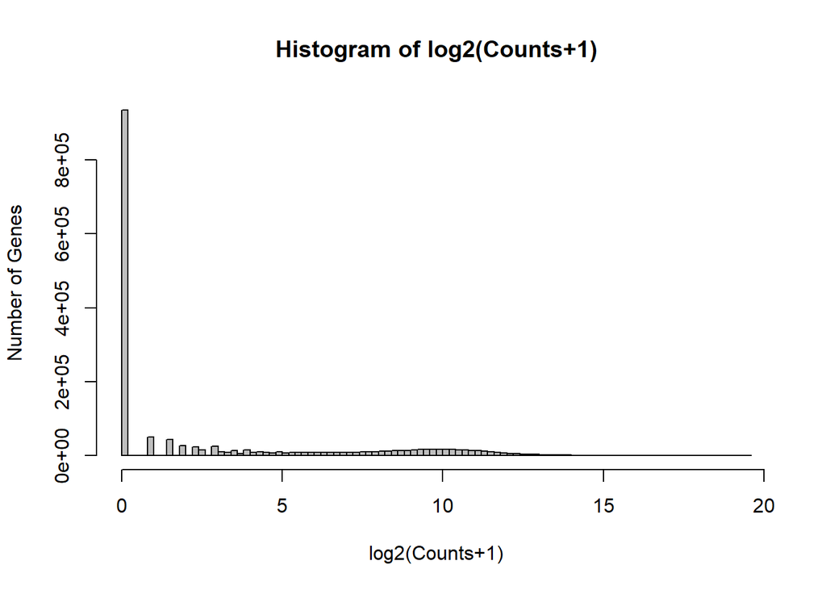

```r
hist(log2(d$counts + 1), breaks=100, xlab = "log2(Counts+1)",
     main="Histogram of log2(Counts+1)", col="grey",
     freq=TRUE,
     ylab="Number of Genes")
```

As expected.

Now, we check the Boxplots for sample-level quality control.

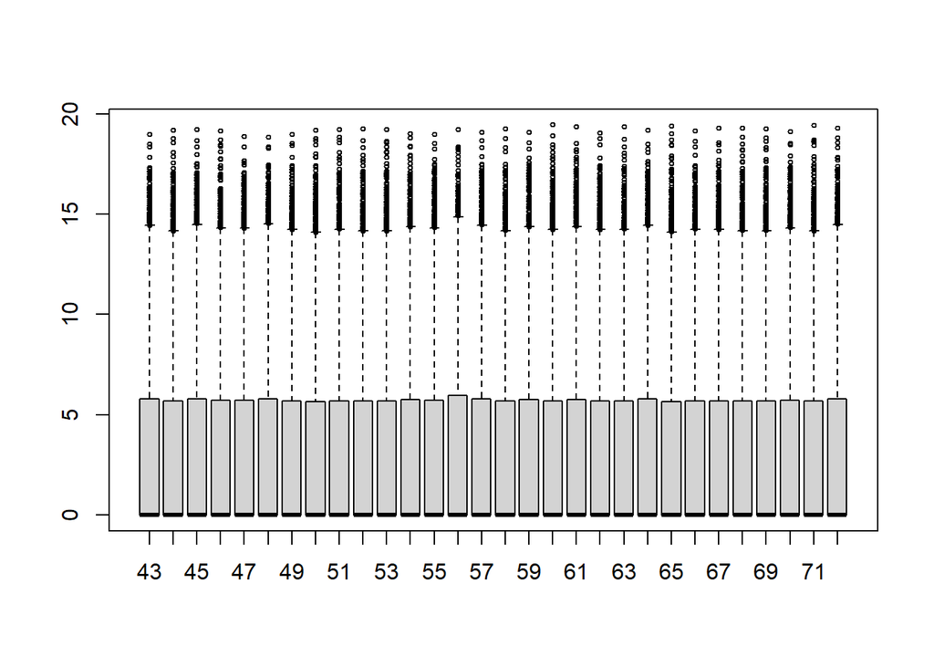

```r
boxplot(log2(d$counts + 1), cex=.5, names=substr(rownames(d$samples), 9, 10))
```

The boxes look very much the same, with very small variances or differences. Similar spread, similar range and no noticeable outliers with extreme values. The weird shape of boxes can be explained by the huge presence of transcripts with 0 expressions, which we saw previously in the histogram.

### Gene-level QC

We first check genes with zero counts in all 30 samples.

```r
# CPM (counts per million)
sum(rowSums(cpm(d))==0)
```

```
## [1] 19850
```

```r
keep <- rowSums(cpm(d) > 1) >= 3
d_filtered <- d[keep, , keep.lib.sizes = TRUE]
nrow(d_filtered)
```

```
## [1] 16077
```

Next we filter duplicates if they exists.

```r
i <- duplicated(d_filtered$genes$Symbol) ; sum(i)
```

```
## [1] 13
```

```r
d_filtered <- d_filtered[-which(i==TRUE), , keep.lib.size = FALSE] ; rm(i)
dim(d_filtered)
```

```
## [1] 16064    30
```

## Normalization

How the Mean Difference plot looks like now, before normalization.

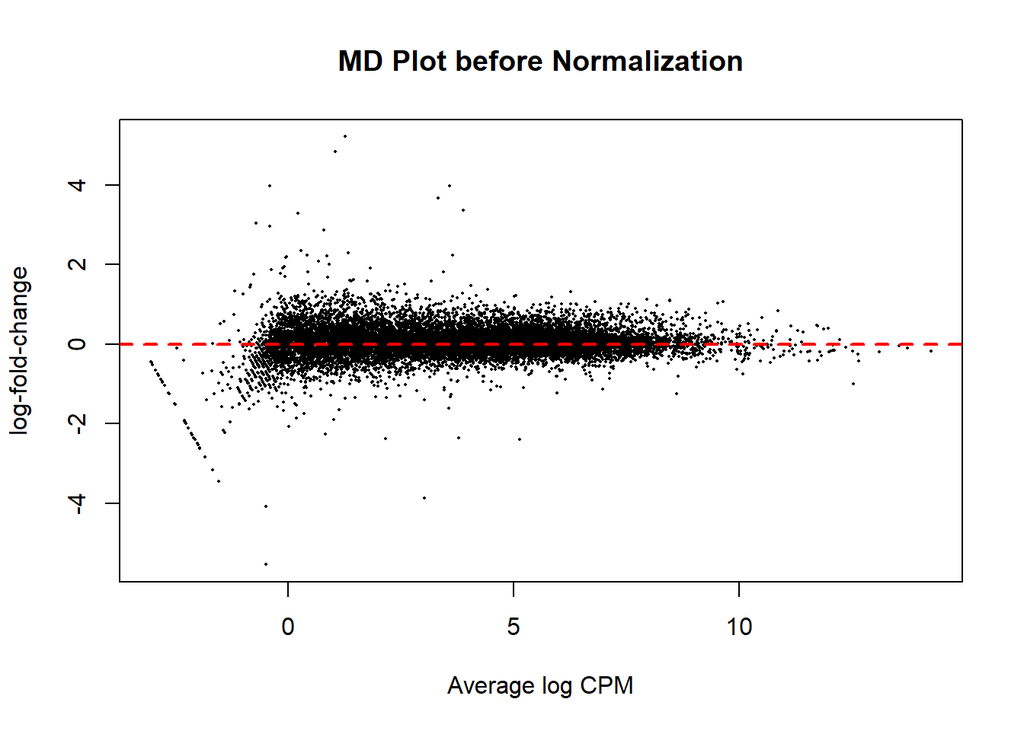

```r
plotMD(d_filtered,
       main = "MD Plot before Normalization",
       xlab = "Average log CPM",
       ylab = "log-fold-change")
abline(h = 0, col = "red", lty = 2, lwd = 2)
```

The points are flattened and close around M=0, which means it is already good data. Although it is not completely centered on M=0, but it is very close. Both `edgeR` and `limma` packages require previous normalization anyway.

Normalization will be performed using the `calcNormFactors()` function from the `edgeR` package, which by default applies the TMM method or ‘Trimmed Mean of M-values’, a method that is quite robust and widely used.

```r
d_filtered <- calcNormFactors(d_filtered)
head(d_filtered$samples)
```

```
##                         group lib.size norm.factors
## GSM9301643     diabetes-prone 28437829     1.032582
## GSM9301644 diabetes-resistant 28524925     0.987236
## GSM9301645     diabetes-prone 29154538     1.017717
## GSM9301646 diabetes-resistant 28492247     1.013674
## GSM9301647     diabetes-prone 28131737     1.026257
## GSM9301648     diabetes-prone 28126022     1.047394
```

Now, we check the boxplot again.

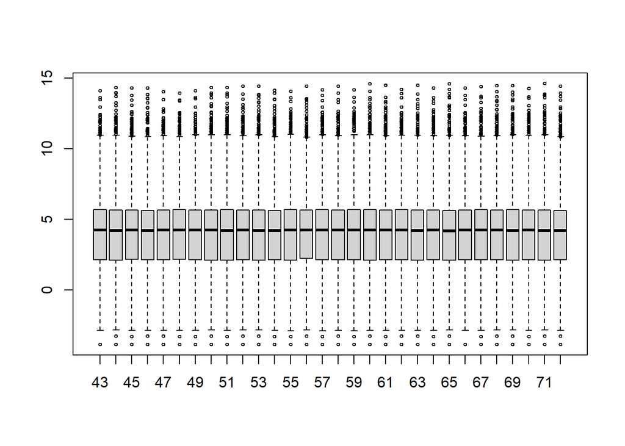

```r
# Get normalized log2 CPM values
logcpm_norm <- cpm(d_filtered, log = TRUE)
boxplot(logcpm_norm, cex=.5, names=substr(rownames(d_filtered$samples), 9, 10))
```

Everything is still aligned and looks better than with raw. The negative y-axis values are due to the log2 transformation.

Now we check again, intensity-dependent bias with MD (Mean Difference) plot.

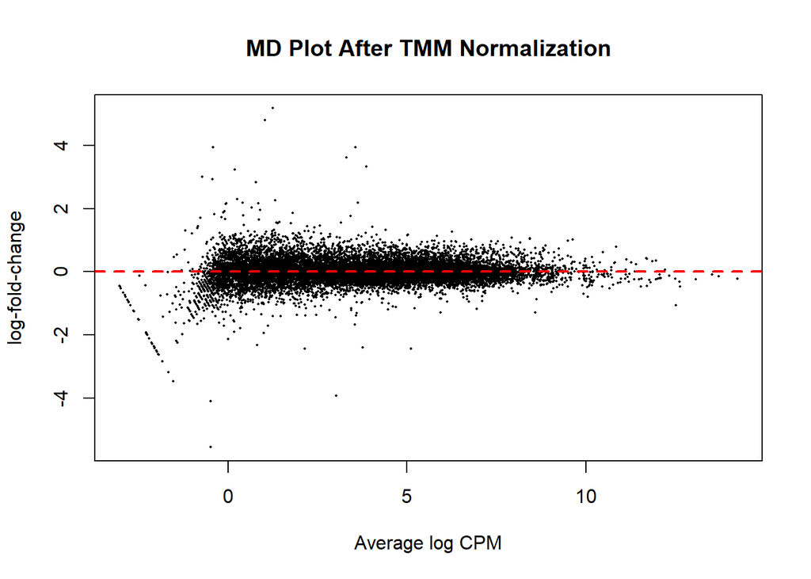

```r
plotMD(d_filtered,
       main = "MD Plot After TMM Normalization",
       xlab = "Average log CPM",
       ylab = "log-fold-change")
abline(h = 0, col = "red", lty = 2, lwd = 2)
```

The points are flattened and centered around M=0, as preious to normalization.

## Exploratory Analysis and Outlier Assessment

We check any change in library sizes, if any.

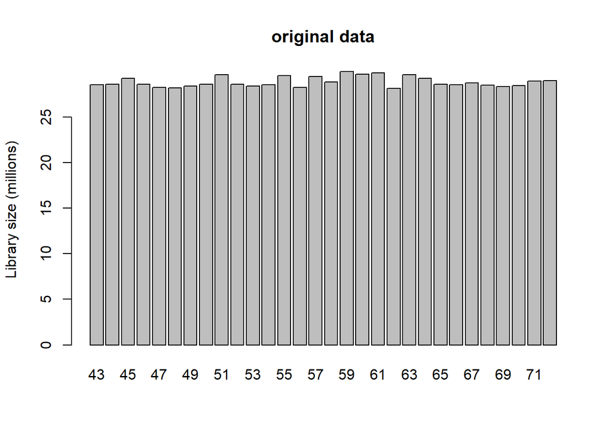

```r
# Library sizes before filtering and normalizing
barplot(d$samples$lib.size*1e-6, names=substr(rownames(d$samples), 9, 10),
        ylab="Library size (millions)", main="original data")
```

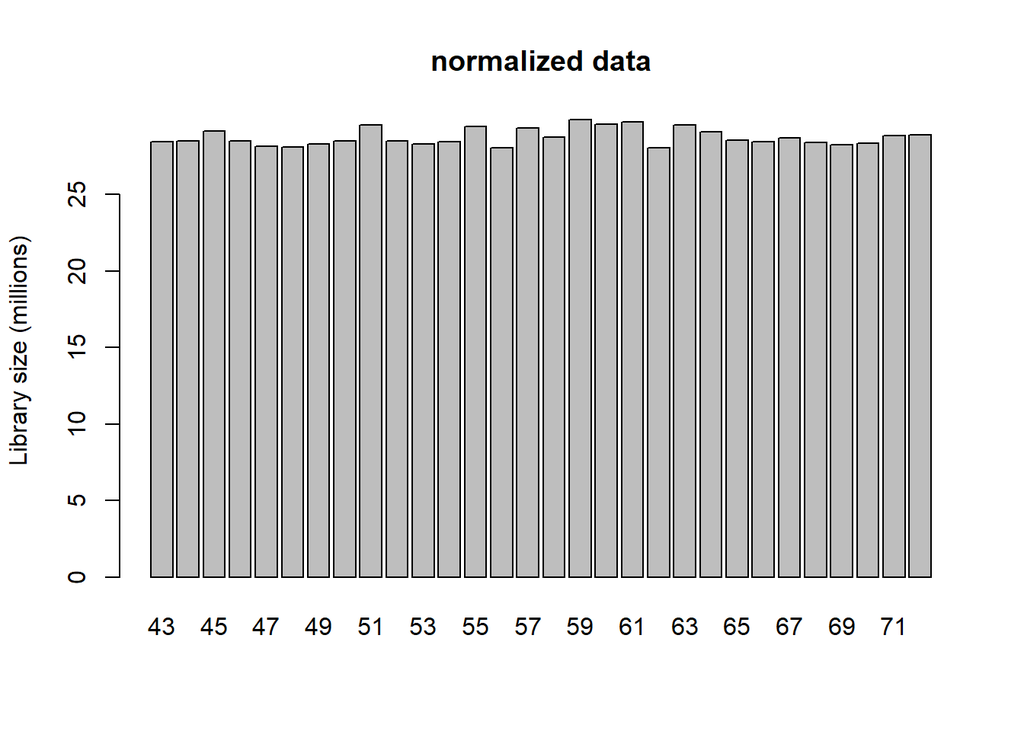

```r
# Library sizes after filtering and normalizing
barplot(d_filtered$samples$lib.size*1e-6, names=substr(rownames(d_filtered$samples), 9, 10),
        ylab="Library size (millions)", main="normalized data")
```

Library sizes remained consistent after TMM normalization, as expected since TMM calculates normalization factors rather than rescaling library sizes.

Multidimensional scaling represent leading log-fold-changes between samples.

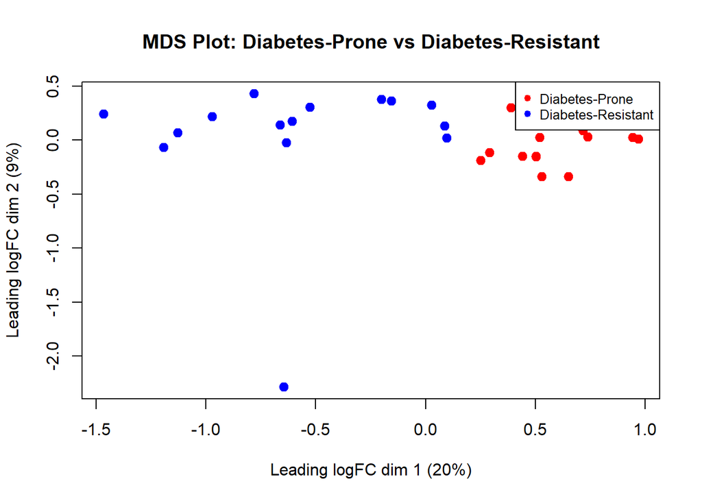

```r
# MDS plot colored by group
plotMDS(d_filtered,
        col = ifelse(d_filtered$samples$group == "diabetes-prone", "red", "blue"),
        pch = 19, cex = 1.2,
        main = "MDS Plot: Diabetes-Prone vs Diabetes-Resistant")

legend("topright",
       legend = c("Diabetes-Prone", "Diabetes-Resistant"),
       col = c("red", "blue"),
       pch = 19,
       cex = 0.8)
```

The MDS plot shows clear separation between diabetes-prone and diabetes-resistant samples along dimension 1, indicating distinct expression profiles between groups. However, there is one sample (diabetes resistant) which is different from all, only noticeable in 2 dimension.

The otulier is.

```r
mds <- plotMDS(d_filtered, plot = FALSE)
dim2 <- mds$y

names(dim2) <- colnames(d_filtered)

# Find the outlier on Dimension 2
dim2_sorted <- sort(dim2)
print(dim2_sorted)
```

```
##  GSM9301656  GSM9301647  GSM9301657  GSM9301645  GSM9301662  GSM9301648
## -2.28519266 -0.33771530 -0.33581152 -0.18641771 -0.15544832 -0.14965358
##  GSM9301670  GSM9301652  GSM9301646  GSM9301663  GSM9301655  GSM9301661
## -0.14956574 -0.11274798 -0.06667597 -0.02130734  0.01158133  0.01960309
##  GSM9301659  GSM9301664  GSM9301643  GSM9301654  GSM9301649  GSM9301660
##  0.02552517  0.02670418  0.03107236  0.07018406  0.08684937  0.12947946
##  GSM9301671  GSM9301658  GSM9301650  GSM9301644  GSM9301665  GSM9301667
##  0.14291648  0.16340798  0.17507110  0.21844844  0.24297471  0.30015445
##  GSM9301653  GSM9301668  GSM9301666  GSM9301651  GSM9301669  GSM9301672
##  0.30714739  0.32541000  0.35200933  0.36565002  0.37710156  0.42924562
```

```r
# Identify the extreme sample
outlier_dim2 <- names(which.max(abs(dim2)))
cat("Sample with extreme Dimension 2:", outlier_dim2, "\n")
```

```
## Sample with extreme Dimension 2: GSM9301656
```

```r
cat("Group:", as.character(d_filtered$samples[outlier_dim2, "group"]), "\n")
```

```
## Group: diabetes-resistant
```

```r
cat("Dim 2 value:", dim2[outlier_dim2], "\n")
```

```
## Dim 2 value: -2.285193
```

I am going to create two datasets one with outlier, and another without.

```r
# Dataset 1: Full data (with outlier)
d_full <- d_filtered

# Dataset 2: Clean data (without outlier)
samples_to_keep <- colnames(d_filtered) != "GSM9301656"
d_clean <- d_filtered[, samples_to_keep]
d_clean$samples$lib.size <- colSums(d_clean$counts)

# Name them clearly
cat("Full dataset:", ncol(d_full), "samples\n")
```

```
## Full dataset: 30 samples
```

```r
cat("Clean dataset:", ncol(d_clean), "samples\n")
```

```
## Clean dataset: 29 samples
```

Later, we will see with differential expression analysis if the supposed outlier makes a difference or not. This will be our sensitivity test.

## Differential Expression (DE)

Two packages `edgeR` and `limma` will be used for modelling, as two separated models. While `edgeR` uses `estimateDisp` for estimate the dispersion and `glmQLFit` to fit log-lineal negative binomial model; `limma` uses `voom` to estimate mean variance, then `lmFit` to fit lineal model and `eBayes` to compute statistics. Both models require a design matrix that converts experimental groups ( “diabetes-prone” and “diabetes-resistant”) into a numerical format. Design matrix is the predictor, meanwhile the count matrix is the outcome we want to predict.

```r
# Function that runs both edgeR and limma analyses
run_my_pipeline <- function(dge_obj, dataset_name) {

  cat("\n", paste(rep("=", 50), collapse=""), "\n")
  cat("Running analysis on:", dataset_name, "\n")
  cat("Samples:", ncol(dge_obj), "\n")
  cat(paste(rep("=", 50), collapse=""), "\n")

  # Design matrix
  design <- model.matrix(~ group, data = dge_obj$samples)

  # edgeR: estimate dispersion
  y <- estimateDisp(dge_obj, design, robust = TRUE)
  cat("\nDispersion summary:\n")
  print(summary(y$tagwise.dispersion))

  # edgeR: QL fit
  fit <- glmQLFit(y, design, robust = TRUE)

  # edgeR: QL F-test
  qlf <- glmQLFTest(fit, coef = 2)

  # edgeR results (top 1000 for quick comparison)
  edgeR_results <- topTags(qlf, n = Inf, sort.by = "PValue")$table
  edgeR_results$gene <- rownames(edgeR_results)

  # limma: voom
  v <- voom(dge_obj, design, plot = TRUE)

  # limma: fit
  lfit <- lmFit(v, design)
  lfit <- eBayes(lfit)

  # limma results
  limma_results <- topTable(lfit, coef = 2, n = Inf, sort.by = "P")
  limma_results$gene <- rownames(limma_results)

  # Return everything
  return(list(
    name = dataset_name,
    n_samples = ncol(dge_obj),
    edgeR = list(
      y = y,
      fit = fit,
      qlf = qlf,
      results = edgeR_results
    ),
    limma = list(
      v = v,
      fit = lfit,
      results = limma_results
    )
  ))
}
```

```r
results_full <- run_my_pipeline(d_full, "Full Dataset (with outlier)")
```

```
##
##  ==================================================
## Running analysis on: Full Dataset (with outlier)
## Samples: 30
## ==================================================
##
## Dispersion summary:
##     Min.  1st Qu.   Median     Mean  3rd Qu.     Max.
##  0.00118  0.00530  0.01158  0.06558  0.03292 52.93079
```

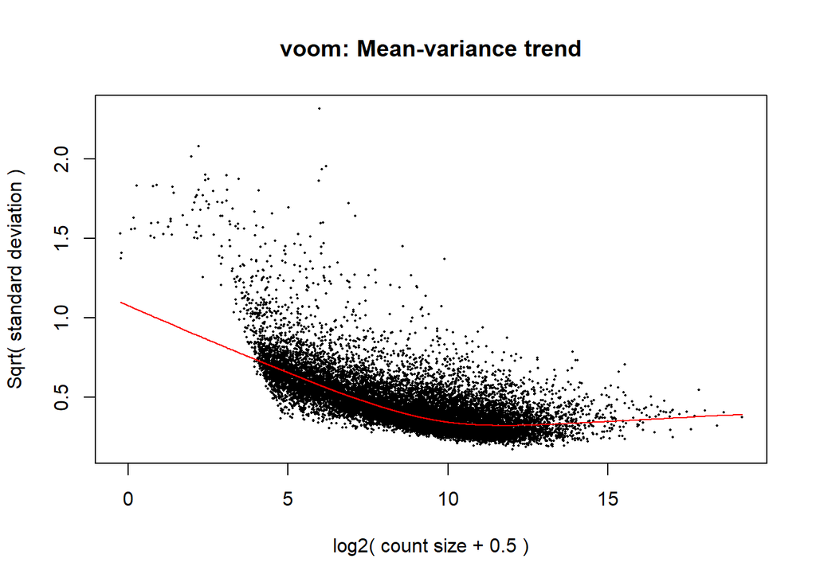

```r
results_clean <- run_my_pipeline(d_clean, "Clean Dataset (without outlier)")
```

```
##
##  ==================================================
## Running analysis on: Clean Dataset (without outlier)
## Samples: 29
## ==================================================
##
## Dispersion summary:
##      Min.   1st Qu.    Median      Mean   3rd Qu.      Max.
##  0.001214  0.005119  0.010985  0.054753  0.031481 29.951018
```

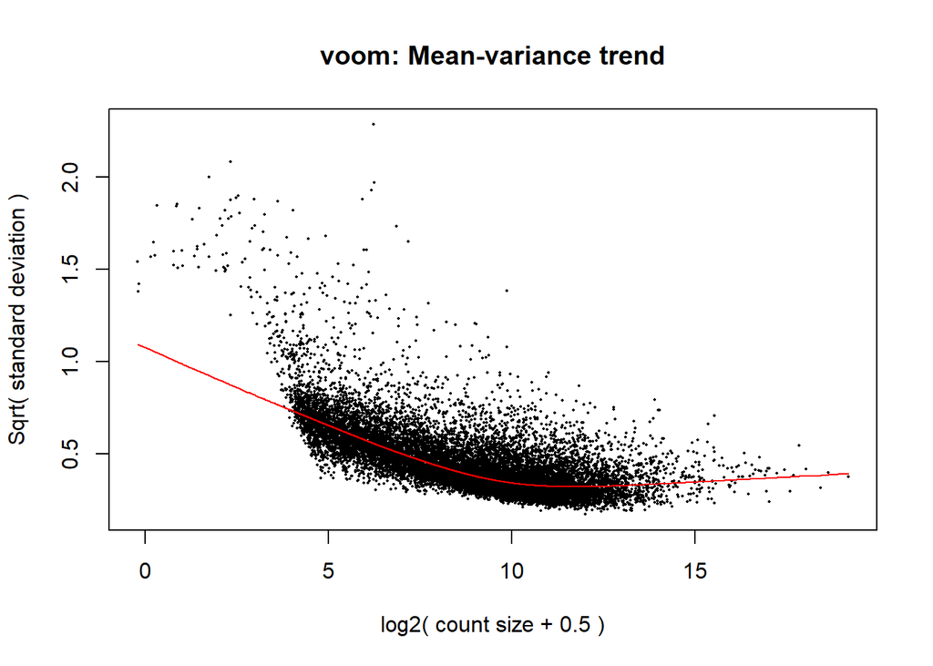

Let’s compare `edgeR` results. We filter DE genes by False Discovery Rate less than 0.05; it means at most 5% of DE gene list is expected to be false. It is better than p-value which only reflects the per-test error rate, and do not take into account the whole DE gene list.

```r
# Get significant genes from edgeR (FDR < 0.05)
sig_edgeR_full <- rownames(results_full$edgeR$results[results_full$edgeR$results$FDR < 0.05, ])
sig_edgeR_clean <- rownames(results_clean$edgeR$results[results_clean$edgeR$results$FDR < 0.05, ])

# 1. Number of DE genes
length(sig_edgeR_full)   # How many DE genes in full dataset
```

```
## [1] 9485
```

```r
length(sig_edgeR_clean)  # How many DE genes in clean dataset
```

```
## [1] 9421
```

```r
# 2. Jaccard similarity/ IoU (0-1, higher = more similar)
length(intersect(sig_edgeR_full, sig_edgeR_clean)) / length(union(sig_edgeR_full, sig_edgeR_clean))
```

```
## [1] 0.9551189
```

```r
# 3. Correlation of logFC (common genes only)
common <- intersect(rownames(results_full$edgeR$results), rownames(results_clean$edgeR$results))
cor(results_full$edgeR$results[common, "logFC"],
    results_clean$edgeR$results[common, "logFC"])
```

```
## [1] 0.9246995
```

The DE genes number are very similar, the similarity of them is also high. However, most importantly is correlation of logFC (Log Fold Change), which is high as well. LogFC measures the relative change in gene expression or feature abundance between two conditions (diabetes-prone and diabetes-resistant), we don’t see the values directly, rather the correlation between two datasets.

Now `limma` results. Instead of FDR, `limma` package presents us with adjusted p-value, similar to FDR. So, we again filter by less than 0.05 `adj.P.Val` .

```r
# Get significant genes from limma (adj.P.Val < 0.05)
sig_limma_full <- rownames(results_full$limma$results[results_full$limma$results$adj.P.Val < 0.05, ])
sig_limma_clean <- rownames(results_clean$limma$results[results_clean$limma$results$adj.P.Val < 0.05, ])

# 1. Number of DE genes
length(sig_limma_full)
```

```
## [1] 9385
```

```r
length(sig_limma_clean)
```

```
## [1] 9345
```

```r
# 2. Jaccard similarity/IoU
length(intersect(sig_limma_full, sig_limma_clean)) / length(union(sig_limma_full, sig_limma_clean))
```

```
## [1] 0.959205
```

```r
# 3. Correlation of logFC
common_limma <- intersect(rownames(results_full$limma$results), rownames(results_clean$limma$results))
cor(results_full$limma$results[common_limma, "logFC"],
    results_clean$limma$results[common_limma, "logFC"])
```

```
## [1] 0.9962574
```

Very much the same as with `edgeR`, and the correlation between logFC is even higher.

Thus, we can conclude that the outlier doesn’t distort significantly the DE modelling, and we can keep the full data for DE genes determination. The difference observed for this particular sample is likely due to natural biological variance rather than technical artifact.

Results from edgeR

```r
top1 <- results_full$edgeR$results
top1 <- top1[top1$FDR < 0.05, ]  # Keep only significant genes
top1 <- top1[order(top1$PValue), ][,c(-1,-8)]  # Sort by p-value
dim(top1)
```

```
## [1] 9485    6
```

```r
head(top1, 20)
```

```
##                      Symbol      logFC    logCPM        F       PValue
## ENSMUSG00000026463   Atp2b4  0.7725626  7.423883 198.8977 3.323294e-15
## ENSMUSG00000061086     Myl4  0.8024293  3.585586 198.2494 3.478517e-15
## ENSMUSG00000027559     Car3  1.4424563 13.209009 186.6532 9.690768e-15
## ENSMUSG00000055782    Abcd2  0.6289680  9.132672 183.1610 1.024100e-14
## ENSMUSG00000030255     Sspn  0.5588563  5.540470 180.9776 1.205020e-14
## ENSMUSG00000022878   Adipoq  1.1179710 10.557434 179.2358 1.607621e-14
## ENSMUSG00000005397     Nid1  0.3169662 10.223606 173.7290 2.093462e-14
## ENSMUSG00000021662 Arhgef28  0.5656127  5.562655 172.2218 2.354072e-14
## ENSMUSG00000019326     Aoc3  0.6409813 10.341875 170.4113 2.713402e-14
## ENSMUSG00000053398    Phgdh  0.6830751  6.417484 170.3016 2.736999e-14
## ENSMUSG00000011382     Dhdh  0.6771878  7.271444 169.5697 2.899925e-14
## ENSMUSG00000022197    Pdzd2  0.7035279  6.918989 159.5662 6.534102e-14
## ENSMUSG00000028785     Hpca -2.0765949  2.052394 159.4097 6.869557e-14
## ENSMUSG00000070003    Ssbp4 -0.4128126  5.688608 158.2939 7.267503e-14
## ENSMUSG00000025092  Hspa12a  0.5491577  7.299036 158.2458 7.296824e-14
## ENSMUSG00000027762   Sucnr1  0.8030847  6.030644 157.8313 7.804157e-14
## ENSMUSG00000033174     Mgll  0.4914099 11.143060 156.6904 8.318542e-14
## ENSMUSG00000022221    Ripk3 -0.7967205  3.782701 155.5218 9.191292e-14
## ENSMUSG00000027386    Fbln7 -1.4045823  3.457957 155.2782 1.025437e-13
## ENSMUSG00000060675   Plaat3  0.6330956  8.722414 151.0901 1.345771e-13
##                             FDR
## ENSMUSG00000026463 2.793945e-11
## ENSMUSG00000061086 2.793945e-11
## ENSMUSG00000027559 3.871489e-11
## ENSMUSG00000055782 3.871489e-11
## ENSMUSG00000030255 3.871489e-11
## ENSMUSG00000022878 4.234945e-11
## ENSMUSG00000005397 4.234945e-11
## ENSMUSG00000021662 4.234945e-11
## ENSMUSG00000019326 4.234945e-11
## ENSMUSG00000053398 4.234945e-11
## ENSMUSG00000011382 4.234945e-11
## ENSMUSG00000022197 7.814412e-11
## ENSMUSG00000028785 7.814412e-11
## ENSMUSG00000070003 7.814412e-11
## ENSMUSG00000025092 7.814412e-11
## ENSMUSG00000027762 7.835374e-11
## ENSMUSG00000033174 7.860533e-11
## ENSMUSG00000022221 8.202718e-11
## ENSMUSG00000027386 8.669797e-11
## ENSMUSG00000060675 1.080923e-10
```

Results from Limma:

```r
top2 <- results_full$limma$results
top2 <- top2[top2$adj.P.Val < 0.05, ]  # Keep only significant genes
top2 <- top2[order(top2$P.Value), ][,c(-1,-9)]  # Sort by p-value
dim(top2)
```

```
## [1] 9385    7
```

```r
head(top2, 20)
```

```
##                      Symbol      logFC   AveExpr         t      P.Value
## ENSMUSG00000026463   Atp2b4  0.7693486  7.364635  14.11242 3.674115e-15
## ENSMUSG00000027559     Car3  1.4464567 13.007366  13.93014 5.237158e-15
## ENSMUSG00000061086     Myl4  0.8001896  3.517039  13.59489 1.014141e-14
## ENSMUSG00000022878   Adipoq  1.1089807 10.433680  13.57937 1.045945e-14
## ENSMUSG00000055782    Abcd2  0.6287134  9.093110  13.55646 1.094761e-14
## ENSMUSG00000030255     Sspn  0.5584313  5.507817  13.41227 1.460770e-14
## ENSMUSG00000005397     Nid1  0.3165990 10.213793  13.32377 1.745616e-14
## ENSMUSG00000021662 Arhgef28  0.5672934  5.528993  13.10959 2.695741e-14
## ENSMUSG00000019326     Aoc3  0.6422092 10.300469  13.05971 2.985040e-14
## ENSMUSG00000011382     Dhdh  0.6793467  7.224638  13.02483 3.206057e-14
## ENSMUSG00000053398    Phgdh  0.6803708  6.369585  12.93103 3.887714e-14
## ENSMUSG00000070003    Ssbp4 -0.4135770  5.669820 -12.70081 6.265609e-14
## ENSMUSG00000033174     Mgll  0.4935819 11.118577  12.68453 6.482166e-14
## ENSMUSG00000022221    Ripk3 -0.8049657  3.711921 -12.67241 6.648320e-14
## ENSMUSG00000025092  Hspa12a  0.5527465  7.267788  12.64049 7.107179e-14
## ENSMUSG00000027762   Sucnr1  0.8017579  5.963820  12.63790 7.145850e-14
## ENSMUSG00000022197    Pdzd2  0.7026463  6.867897  12.54247 8.730215e-14
## ENSMUSG00000060675   Plaat3  0.6344728  8.681003  12.43138 1.103662e-13
## ENSMUSG00000028785     Hpca -2.2534358  1.578519 -12.32686 1.377795e-13
## ENSMUSG00000033849  B3galt2  0.9049215  6.906106  12.32392 1.386423e-13
##                       adj.P.Val        B
## ENSMUSG00000026463 3.517249e-11 24.56474
## ENSMUSG00000027559 3.517249e-11 23.96204
## ENSMUSG00000061086 3.517249e-11 23.02368
## ENSMUSG00000022878 3.517249e-11 23.46531
## ENSMUSG00000055782 3.517249e-11 23.46813
## ENSMUSG00000030255 3.910969e-11 23.19141
## ENSMUSG00000005397 4.005940e-11 22.98043
## ENSMUSG00000021662 5.150209e-11 22.59506
## ENSMUSG00000019326 5.150209e-11 22.45852
## ENSMUSG00000011382 5.150209e-11 22.44328
## ENSMUSG00000053398 5.677477e-11 22.25253
## ENSMUSG00000070003 7.174434e-11 21.77537
## ENSMUSG00000033174 7.174434e-11 21.68078
## ENSMUSG00000022221 7.174434e-11 21.39013
## ENSMUSG00000025092 7.174434e-11 21.66051
## ENSMUSG00000027762 7.174434e-11 21.65067
## ENSMUSG00000022197 8.249540e-11 21.45819
## ENSMUSG00000060675 9.849567e-11 21.21980
## ENSMUSG00000028785 1.095377e-10 18.39294
## ENSMUSG00000033849 1.095377e-10 21.00240
```

Method agreement.

```r
shared <- intersect(rownames(top1), rownames(top2))
length(shared)
```

```
## [1] 9295
```

Selection where both methods agree.

```r
top <- top1[rownames(top1) %in% shared, ]
dim(top)
```

```
## [1] 9295    6
```

```r
head(top, 20)
```

```
##                      Symbol      logFC    logCPM        F       PValue
## ENSMUSG00000026463   Atp2b4  0.7725626  7.423883 198.8977 3.323294e-15
## ENSMUSG00000061086     Myl4  0.8024293  3.585586 198.2494 3.478517e-15
## ENSMUSG00000027559     Car3  1.4424563 13.209009 186.6532 9.690768e-15
## ENSMUSG00000055782    Abcd2  0.6289680  9.132672 183.1610 1.024100e-14
## ENSMUSG00000030255     Sspn  0.5588563  5.540470 180.9776 1.205020e-14
## ENSMUSG00000022878   Adipoq  1.1179710 10.557434 179.2358 1.607621e-14
## ENSMUSG00000005397     Nid1  0.3169662 10.223606 173.7290 2.093462e-14
## ENSMUSG00000021662 Arhgef28  0.5656127  5.562655 172.2218 2.354072e-14
## ENSMUSG00000019326     Aoc3  0.6409813 10.341875 170.4113 2.713402e-14
## ENSMUSG00000053398    Phgdh  0.6830751  6.417484 170.3016 2.736999e-14
## ENSMUSG00000011382     Dhdh  0.6771878  7.271444 169.5697 2.899925e-14
## ENSMUSG00000022197    Pdzd2  0.7035279  6.918989 159.5662 6.534102e-14
## ENSMUSG00000028785     Hpca -2.0765949  2.052394 159.4097 6.869557e-14
## ENSMUSG00000070003    Ssbp4 -0.4128126  5.688608 158.2939 7.267503e-14
## ENSMUSG00000025092  Hspa12a  0.5491577  7.299036 158.2458 7.296824e-14
## ENSMUSG00000027762   Sucnr1  0.8030847  6.030644 157.8313 7.804157e-14
## ENSMUSG00000033174     Mgll  0.4914099 11.143060 156.6904 8.318542e-14
## ENSMUSG00000022221    Ripk3 -0.7967205  3.782701 155.5218 9.191292e-14
## ENSMUSG00000027386    Fbln7 -1.4045823  3.457957 155.2782 1.025437e-13
## ENSMUSG00000060675   Plaat3  0.6330956  8.722414 151.0901 1.345771e-13
##                             FDR
## ENSMUSG00000026463 2.793945e-11
## ENSMUSG00000061086 2.793945e-11
## ENSMUSG00000027559 3.871489e-11
## ENSMUSG00000055782 3.871489e-11
## ENSMUSG00000030255 3.871489e-11
## ENSMUSG00000022878 4.234945e-11
## ENSMUSG00000005397 4.234945e-11
## ENSMUSG00000021662 4.234945e-11
## ENSMUSG00000019326 4.234945e-11
## ENSMUSG00000053398 4.234945e-11
## ENSMUSG00000011382 4.234945e-11
## ENSMUSG00000022197 7.814412e-11
## ENSMUSG00000028785 7.814412e-11
## ENSMUSG00000070003 7.814412e-11
## ENSMUSG00000025092 7.814412e-11
## ENSMUSG00000027762 7.835374e-11
## ENSMUSG00000033174 7.860533e-11
## ENSMUSG00000022221 8.202718e-11
## ENSMUSG00000027386 8.669797e-11
## ENSMUSG00000060675 1.080923e-10
```

### MA plots

An MA plot visualizes differential expression by plotting log fold change (M) against average expression (A), with most genes centered near zero. It is used to assess normalization quality, identify differentially expressed genes, and detect intensity-dependent bias such as fan-shaped trends.

[figure not shown]

```r
# MA plot for edgeR using full dataset
plotMD(results_full$edgeR$qlf,
       status = decideTests(results_full$edgeR$qlf),
       main = "edgeR: Differentially Expressed Genes (Full Dataset)",
       legend = FALSE,
       xlab = "Average log2 CPM",
       ylab = "log2 Fold Change")
abline(h = c(-1, 1), col = "blue", lty = 2, lwd = 1.5)
abline(h = 0, col = "red", lty = 2, lwd = 1)

legend("topright",
       legend = c("Up in Prone", "Down in Prone", "Not DE"),
       col = c("red", "blue", "black"),
       pch = 20, cex = 0.8)
```

Limma based MA plot.

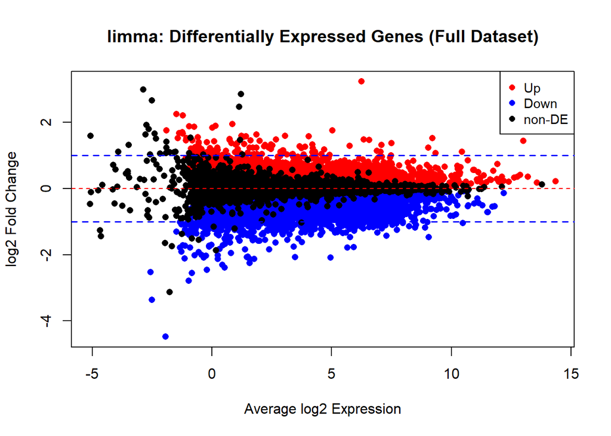

```r
# MA plot for limma using full dataset
# Create status vector for limma results
status <- decideTests(results_full$limma$fit)[, 2]
status[status == 0] <- "non-DE"
status[status == 1] <- "Up"
status[status == -1] <- "Down"

plotMD(results_full$limma$fit,
       column = 2,
       hl.col = c("red", "blue", "black"),
       values = c("Up", "Down", "non-DE"),
       status = status,
       main = "limma: Differentially Expressed Genes (Full Dataset)",
       xlab = "Average log2 Expression",
       ylab = "log2 Fold Change")
abline(h = c(-1, 1), col = "blue", lty = 2, lwd = 1.5)
abline(h = 0, col = "red", lty = 2, lwd = 1)
```

Presents more non-DE than `edgeR` model!

### Volcano plot

A volcano plot displays statistical significance (-log10 FDR) against effect size (log fold change), allowing immediate visualization of both metrics simultaneously. It is used to identify differentially expressed genes with large magnitude changes and high confidence, while also providing a quality control check for balanced up/down regulation.

We use here the agreement between the models.

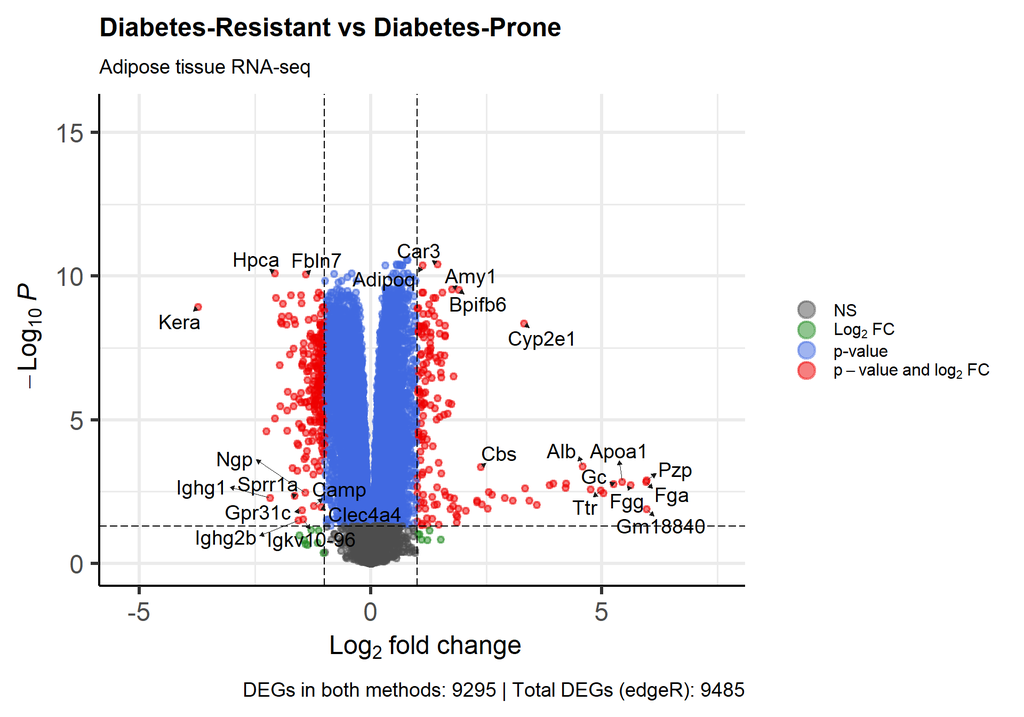

```r
library(EnhancedVolcano)
# Create a combined results table with all genes
all_genes <- results_full$edgeR$results

# Add column for method agreement
all_genes$method_agreement <- "Only edgeR"
all_genes$method_agreement[rownames(all_genes) %in% rownames(top2)] <- "Both methods"
all_genes$method_agreement[all_genes$FDR >= 0.05] <- "Not significant"

# Custom volcano plot
EnhancedVolcano(all_genes,
                lab = all_genes$Symbol,
                x = "logFC",
                y = "FDR",
                pCutoff = 0.05,
                FCcutoff = 1.0,
                title = "Diabetes-Resistant vs Diabetes-Prone",
                subtitle = "Adipose tissue RNA-seq",
                caption = paste0("DEGs in both methods: ", nrow(top),
                                " | Total DEGs (edgeR): ", sum(all_genes$FDR < 0.05)),
                legendPosition = "right",
                legendLabSize = 12,
                colAlpha = 0.5,
                pointSize = 1.5,
                drawConnectors = TRUE,
                widthConnectors = 0.3,
                max.overlaps = 20)
```

### Heatmap

First, we selected genes with logFC.

```r
sel_genes <- rownames(top[which((top$logFC>=1) | (top$logFC<=-1)),]) ; length(sel_genes)
```

```
## [1] 363
```

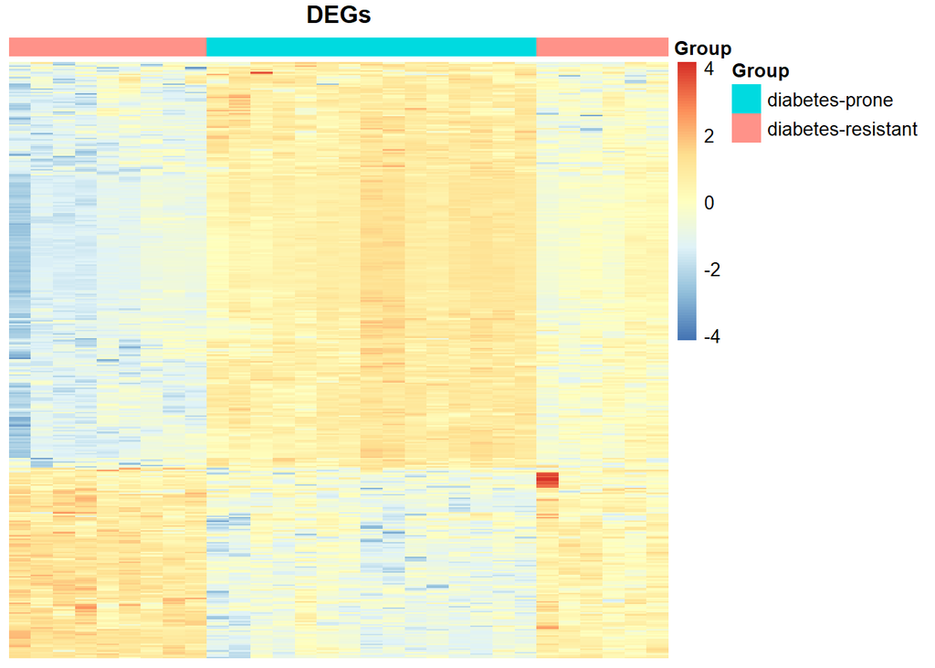

```r
# Get symbols
sel_symbols <- gsub(".*\\|", "", names(sel_genes))

design <- model.matrix(~ group, data = d_full$samples)
y <- estimateDisp(d_full, design, robust = TRUE)

# Subset and label heatmap data
heatmap_data <- cpm(y, log = TRUE)[sel_genes, ]
rownames(heatmap_data) <- sel_symbols

# Sample annotation
annotation_col <- data.frame(Group = y$samples$group,
                             row.names = colnames(heatmap_data))

# Heatmap
library(pheatmap)
pheatmap(heatmap_data,
         annotation_col = annotation_col,
         scale = "row",
         cluster_rows = TRUE,
         cluster_cols = TRUE,
         treeheight_row = 0,
         treeheight_col = 0,
         show_rownames = TRUE,
         show_colnames = FALSE,
         fontsize_row = 4,
         main = "DEGs")
```

The heatmap shows two blocks within this `sel_genes` number, both opposite to each other when expressing in prone and non-prone to diabetes mice. The switch of those genes is almost the opposite in all samples.

## Annotation and Enrichment

### GO and KEGG

Now we will analyze the biological significance, using enrichment with two databases: **GO** o *Gene Ontology*[^3] y **KEGG** o *Kyoto Encyclopedia of Genes and Genomes*[^4]. The first brings together molecular functions, cellular components, and biological processes; while the second is oriented toward metabolic pathways.

To collect information from the databases, the functions of the `limma` package, such as `goana()` and `kegga`, allow it to be done directly on the model. But since there is only one limma model, the genes selected previously will be used, which, in addition to being significant and shared by the two models used in the report, have logFC > |1|.

We need *Entrez* format, so we check it first.

```r
# Check format
head(sel_genes)
```

```
## [1] "ENSMUSG00000027559" "ENSMUSG00000022878" "ENSMUSG00000028785"
## [4] "ENSMUSG00000027386" "ENSMUSG00000074264" "ENSMUSG00000068009"
```

They start with “ENSMUSG” (not *Entrez* format), so we convert them:

```r
library(org.Mm.eg.db)

# Convert Ensembl to Entrez
entrez_ids <- mapIds(org.Mm.eg.db,
                     keys = sel_genes,
                     column = "ENTREZID",
                     keytype = "ENSEMBL")
# Remove NAs
entrez_ids <- entrez_ids[!is.na(entrez_ids)]
length(entrez_ids)
```

```
## [1] 328
```

Now, we do the search in both databases for the IDs.

```r
go <- goana(entrez_ids, species = "Mm") ; dim(go)
```

```
## [1] 22692     5
```

```r
kegg <- kegga(entrez_ids, species = "Mm") ; dim(kegg)
```

```
## [1] 367   4
```

Now we generate top list from both databases matches.

```r
GO <- topGO(go, ont="BP", n=25)#[1:3]
KEGG <- topKEGG(kegg, n=25)#[1:2]

require(pander)
pander(GO, emphasize.rownames=FALSE, split.table = Inf)
```

|  | Term | Ont | N | DE | P.DE |
| --- | --- | --- | --- | --- | --- |
| GO:0065007 | biological regulation | BP | 13267 | 234 | 4.798e-25 |
| GO:0050789 | regulation of biological process | BP | 12842 | 226 | 3.323e-23 |
| GO:0009987 | cellular process | BP | 17654 | 270 | 4.708e-22 |
| GO:0050896 | response to stimulus | BP | 10589 | 196 | 9.67e-21 |
| GO:0050794 | regulation of cellular process | BP | 12182 | 213 | 2.348e-20 |
| GO:0048583 | regulation of response to stimulus | BP | 4280 | 110 | 2.09e-19 |
| GO:0048518 | positive regulation of biological process | BP | 6761 | 145 | 3.657e-19 |
| GO:0006952 | defense response | BP | 1976 | 69 | 2.198e-18 |
| GO:0007154 | cell communication | BP | 7407 | 149 | 3.563e-17 |
| GO:0048522 | positive regulation of cellular process | BP | 6145 | 132 | 4.439e-17 |
| GO:0023052 | signaling | BP | 7371 | 148 | 6.006e-17 |
| GO:0051716 | cellular response to stimulus | BP | 8443 | 161 | 1.065e-16 |
| GO:0007165 | signal transduction | BP | 6749 | 139 | 1.369e-16 |
| GO:0002682 | regulation of immune system process | BP | 1743 | 61 | 2.734e-16 |
| GO:0007166 | cell surface receptor signaling pathway | BP | 2880 | 81 | 4.318e-16 |
| GO:0051239 | regulation of multicellular organismal process | BP | 3326 | 88 | 6.175e-16 |
| GO:0009605 | response to external stimulus | BP | 2790 | 79 | 7.685e-16 |
| GO:0006954 | inflammatory response | BP | 887 | 41 | 4.886e-15 |
| GO:0002376 | immune system process | BP | 3100 | 82 | 8.658e-15 |
| GO:0006950 | response to stress | BP | 4207 | 99 | 1.019e-14 |
| GO:0032501 | multicellular organismal process | BP | 8756 | 159 | 2.237e-14 |
| GO:0009966 | regulation of signal transduction | BP | 3221 | 83 | 2.435e-14 |
| GO:0051240 | positive regulation of multicellular organismal process | BP | 1936 | 61 | 3.159e-14 |
| GO:0051234 | establishment of localization | BP | 4819 | 106 | 6.882e-14 |
| GO:1903555 | regulation of tumor necrosis factor superfamily cytokine production | BP | 202 | 20 | 8.392e-14 |

Ontological GO category: BP = Biological Process, MF = Molecular Function, CC = Cellular Component. *N* is total genes annotated, and *DE* is differentially expressed genes. *P.DE*: p-value.

The table maybe overwhelming, so we could represent top 25 GO terms in a dot plot.

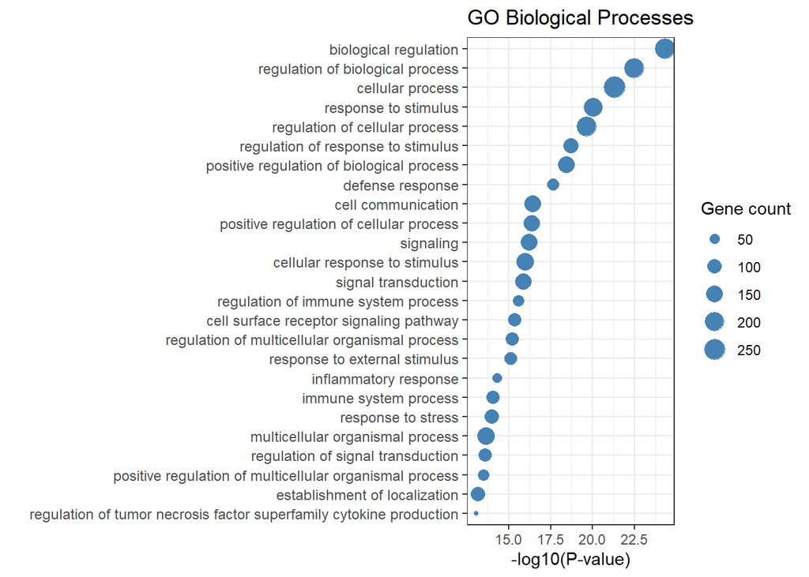

```r
library(ggplot2)

go_plot <- GO


# Calculate log10 P-value
go_plot$logP <- -log10(go_plot$P.DE)

# Plot
ggplot(go_plot, aes(x = logP, y = reorder(Term, logP))) +
    geom_point(aes(size = DE), color = "steelblue") +
    labs(x = "-log10(P-value)",
         y = "",
         size = "Gene count",
         title = "GO Biological Processes") +
    theme_bw() +
    theme(axis.text.y = element_text(size = 9))
```

Now check the metabolic pathways.

```r
pander(KEGG, split.table = Inf)
```

|  | Pathway | N | DE | P.DE |
| --- | --- | --- | --- | --- |
| **mmu04380** | Osteoclast differentiation | 132 | 16 | 5.113e-11 |
| **mmu04662** | B cell receptor signaling pathway | 80 | 8 | 1.728e-05 |
| **mmu03260** | Virion - Human immunodeficiency virus | 10 | 3 | 0.0003163 |
| **mmu00983** | Drug metabolism - other enzymes | 96 | 7 | 0.0004302 |
| **mmu04657** | IL-17 signaling pathway | 97 | 7 | 0.0004582 |
| **mmu00982** | Drug metabolism - cytochrome P450 | 72 | 5 | 0.003577 |
| **mmu04145** | Phagosome | 181 | 8 | 0.004349 |
| **mmu00980** | Metabolism of xenobiotics by cytochrome P450 | 76 | 5 | 0.004514 |
| **mmu00650** | Butanoate metabolism | 27 | 3 | 0.006457 |
| **mmu05323** | Rheumatoid arthritis | 87 | 5 | 0.007972 |
| **mmu04970** | Salivary secretion | 87 | 5 | 0.007972 |
| **mmu05204** | Chemical carcinogenesis - DNA adducts | 90 | 5 | 0.009167 |
| **mmu04060** | Cytokine-cytokine receptor interaction | 294 | 10 | 0.00937 |
| **mmu00512** | Mucin type O-glycan biosynthesis | 32 | 3 | 0.0104 |
| **mmu04517** | IgSF CAM signaling | 300 | 10 | 0.0107 |
| **mmu05150** | Staphylococcus aureus infection | 131 | 6 | 0.01104 |
| **mmu03264** | Virion - Flavivirus and Alphavirus | 13 | 2 | 0.01419 |
| **mmu05152** | Tuberculosis | 180 | 7 | 0.0145 |
| **mmu00480** | Glutathione metabolism | 73 | 4 | 0.02019 |
| **mmu04814** | Motor proteins | 198 | 7 | 0.02317 |
| **mmu00910** | Nitrogen metabolism | 17 | 2 | 0.02384 |
| **mmu03265** | Virion - Ebolavirus, Lyssavirus and Morbillivirus | 17 | 2 | 0.02384 |
| **mmu01524** | Platinum drug resistance | 81 | 4 | 0.02831 |
| **mmu03273** | Virion - Lassa virus and SFTS virus | 21 | 2 | 0.03548 |
| **mmu05417** | Lipid and atherosclerosis | 217 | 7 | 0.03564 |

KEGG dot plot.

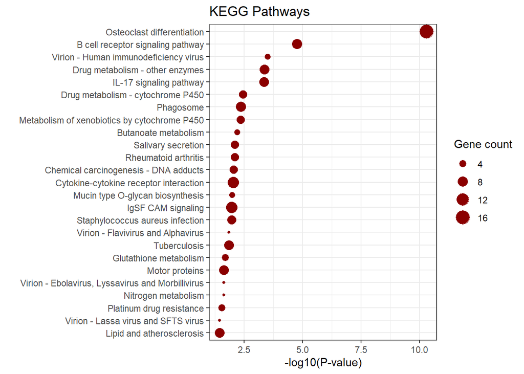

```r
kegg_plot <- KEGG#[1:20, ]
kegg_plot$logP <- -log10(kegg_plot$P.DE)

ggplot(kegg_plot, aes(x = logP, y = reorder(Pathway, logP))) +
    geom_point(aes(size = DE), color = "darkred") +
    labs(x = "-log10(P-value)", y = "", size = "Gene count",
         title = "KEGG Pathways") +
    theme_bw()
```

Many terms are related to immune system, in both lists (GO and KEGG).

We could also try to search for diabetes related terms like “insulin”, “glucose” or “diabetes” itself.

Check the diabetic terms within GO terms.

```r
# Search GO terms for diabetes-related keywords
keywords <- "insulin|glucose|diabetes"

diabetes_go <- go[grep(keywords, go$Term, ignore.case = TRUE), ]

# Show top hits sorted by P-value
diabetes_go <- diabetes_go[order(diabetes_go$P.DE), ]
head(diabetes_go[], 20)
```

```
##                                                                Term Ont   N DE
## GO:0009749                                      response to glucose  BP 254  8
## GO:0001678                        intracellular glucose homeostasis  BP 211  7
## GO:0042593                                      glucose homeostasis  BP 332  9
## GO:0030073                                        insulin secretion  BP 275  7
## GO:0015152   glucose-6-phosphate transmembrane transporter activity  MF   3  1
## GO:0061513        glucose 6-phosphate:phosphate antiporter activity  MF   3  1
## GO:0032024                 positive regulation of insulin secretion  BP 120  4
## GO:0032868                                      response to insulin  BP 308  7
## GO:0015760                            glucose-6-phosphate transport  BP   5  1
## GO:0071333                    cellular response to glucose stimulus  BP 192  5
## GO:0010827          regulation of D-glucose transmembrane transport  BP  92  3
## GO:0046326                  positive regulation of D-glucose import  BP  46  2
## GO:0050796                          regulation of insulin secretion  BP 232  5
## GO:0010828 positive regulation of D-glucose transmembrane transport  BP  56  2
## GO:0006006                                glucose metabolic process  BP 248  5
## GO:0005536                                        D-glucose binding  MF  14  1
## GO:1904659                        D-glucose transmembrane transport  BP 126  3
## GO:0046324                           regulation of D-glucose import  BP  71  2
## GO:0046323                                         D-glucose import  BP  91  2
## GO:0032869                    cellular response to insulin stimulus  BP 242  4
##                   P.DE
## GO:0009749 0.006563250
## GO:0001678 0.008190555
## GO:0042593 0.010371477
## GO:0030073 0.030240906
## GO:0015152 0.031984292
## GO:0061513 0.031984292
## GO:0032024 0.041169692
## GO:0032868 0.050348989
## GO:0015760 0.052738508
## GO:0071333 0.057499667
## GO:0010827 0.077452138
## GO:0046326 0.087960310
## GO:0050796 0.106976440
## GO:0010828 0.122212953
## GO:0006006 0.131168751
## GO:0005536 0.140777399
## GO:1904659 0.155258430
## GO:0046324 0.178176594
## GO:0046323 0.257077840
## GO:0032869 0.264910132
```

```r
dim(diabetes_go)
```

```
## [1] 127   5
```

Ontological GO category: BP = Biological Process, MF = Molecular Function, CC = Cellular Component. *N* is total genes annotated, and *DE* is differentially expressed genes. *P.DE*: p-value.

We can clearly see there are such terms, exactly 127 terms.

Check the diabetic terms within KEGG pathways.

```r
diabetes_kegg <- kegg[grep(keywords, kegg$Pathway, ignore.case = TRUE), ]

# Show results
diabetes_kegg[, ]
```

```
##                                       Pathway   N DE      P.DE
## mmu04910            Insulin signaling pathway 140  3 0.3217668
## mmu04911                    Insulin secretion  86  1 0.7102471
## mmu04930            Type II diabetes mellitus  48  2 0.1491552
## mmu04931                   Insulin resistance 110  3 0.2067881
## mmu04940             Type I diabetes mellitus  65  0 1.0000000
## mmu04950 Maturity onset diabetes of the young  27  0 1.0000000
```

```r
dim(diabetes_kegg)
```

```
## [1] 6 4
```

Here there are such terms as well, but much less, only 6. Most of these are related to insulin and diabetes.

## Summary

During the analysis we identified one sample outlier with MDS analysis. However, after modelling comparison or sensitivity test, this outlier or this particular sample present some differences that may be due to the biological variance rather than technical artifacts.

A close check of DEGs by using the enrichment, show us not only just diabetes and insulin related genes, but the immuno-related genes (immuno response, defense, inflammatory response, B cell receptor, IL-17, etc).

[^1]: https://www.ncbi.nlm.nih.gov/geo/query/acc.cgi?acc=GSE310456
[^2]: https://stat.ethz.ch/pipermail/bioconductor/2014-May/059309.html
[^3]: http://geneontology.org/
[^4]: https://www.genome.jp/kegg/